# Enem 2019 - Alura

Lucas Prado

Novembro/2020

## Projeto Análises do Enem 2019

As análises realizadas fazem parte de um projeto de Imersão de Dados promovida pela Alura em Outubro de 2020.

O dataset foi baseado nos dados do INEP, o qual a equipe da Alura extraiu uma amostra de cerca de 127.000 estudantes.

O evento foi programado em Python, porém, elevei o desafio ao utilizar a linguagem R. Desta forma, tive a oportunidade de entrar em contato simultaneamente com as duas linguagens e observar suas nuances.

#### Bibliotecas Utilizadas

- dplyr
- ggplot2
- knitr
- tidyr
- geobr
- Hmisc
- ggspatial
- gmodels
- magrittr
- reshape2
- plotly
- lattice
- RColorBrewer

### Análise Exploratória de Dados Sociais

##### Nesta etapa inicial, vamos conhecer mais sobre o conjunto de dados:

- 1. Quantos registros e variáveis temos em nosso DataSet?
- 2. Qual o perfil de gênero?
- 3. Como é o perfil de idade?
- 4. Como a renda está distribuída?

#### **1.** A dimensão do DataSet é

```r
dim(dfEnem)
```

```
## [1] 127380    136
```

#### **2.** Perfil de gênero:

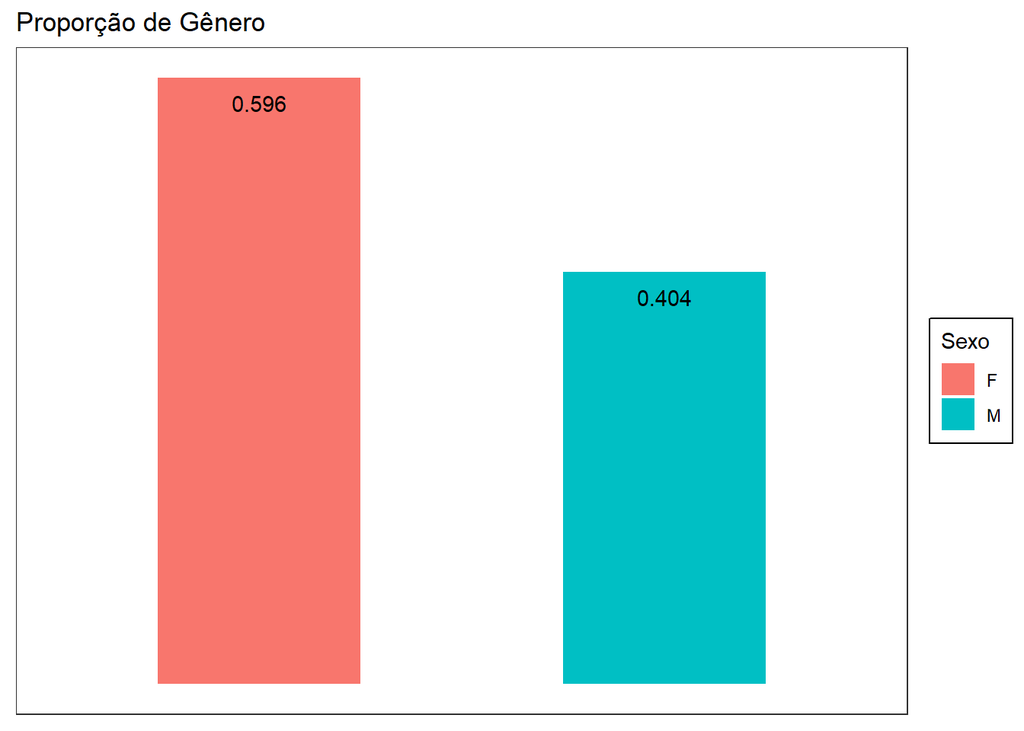

```r
Genero <- dfEnem["TP_SEXO"]
Genero$TP_SEXO <- as.factor(Genero$TP_SEXO)
Genero$Total <- 1
 ggplot(Genero,aes(x=TP_SEXO)) +
   geom_bar(stat="count", width =0.5, aes(fill=TP_SEXO)) +
   ggtitle("Proporção de Gênero")+
   labs(fill="Sexo")+
  geom_text(stat='count',aes(label=round((..count..)/sum(..count..),3)),vjust=2)+
   theme_bw()+
   theme(
     panel.grid = element_blank(),
    legend.background = element_rect(fill = "transparent"),
    legend.box.background = element_rect(fill = "transparent"),
    axis.text = element_blank(),
    axis.ticks= element_blank(),
    axis.line = element_blank(),
    axis.title = element_blank())
```

> As mulheres são maioria das participantes do Enem 2019 representando 60%

#### Medidas de Posição das Idades

```r
summary(dfEnem$NU_IDADE)
```

```
##    Min. 1st Qu.  Median    Mean 3rd Qu.    Max.
##   13.00   18.00   19.00   22.09   24.00   82.00
```

#### **3.** Histograma das Idades

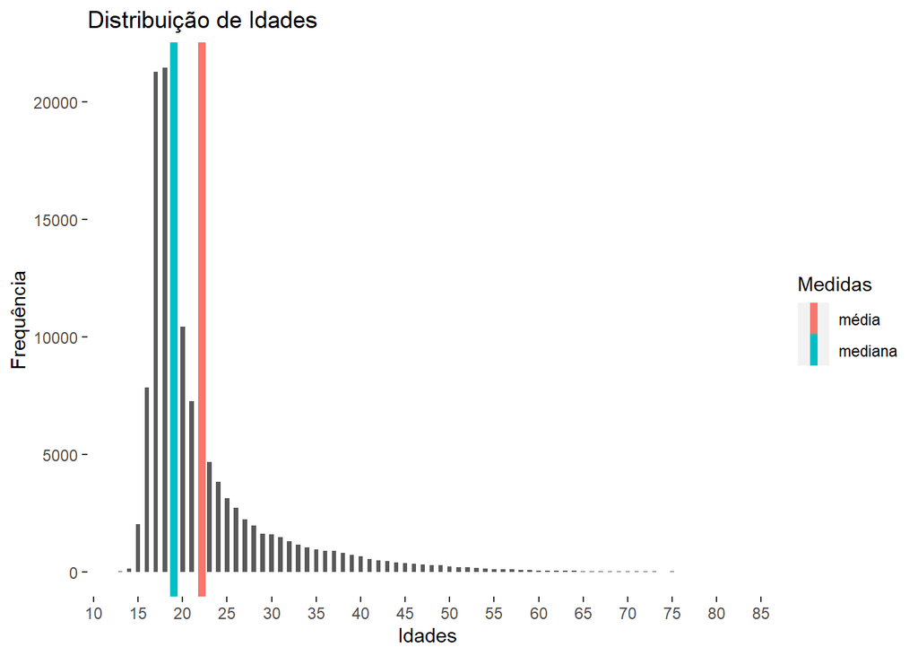

```r
Idades <- dfEnem$NU_IDADE


ggplot(dfEnem,aes(NU_IDADE))+geom_histogram(binwidth = .5)+
        scale_x_continuous(breaks = seq(0, 100, 5))+
        ggtitle("Distribuição de Idades")+
        labs(x="Idades",y="Frequência")+
        geom_vline(aes(xintercept=mean(NU_IDADE),color="média"),show.legend = T,size=2)+
        geom_vline(aes(xintercept=median(NU_IDADE),color="mediana"),show.legend = T,size=2)+
        theme(panel.grid.major = element_blank(),
              panel.border = element_blank(),
              panel.background = element_blank()
              )+scale_color_discrete(name = "Medidas")
```

> Interessante notar que existem um número considerável de pessoas acima de 25 anos fazendo o Enem. Certamente parte delas querem mudar seu rumo profissional e também há professores que querem testar a prova.

### **4.** Como a renda está distribuída?

#### 4.1 Criando Tabela de Referência da Classe Social

```r
knitr::kable(dfRenda, format = "simple")
```

| Perfil | Renda |
| --- | --- |
| A | Nenhuma |
| B | Até R$998 |
| C | R$ 998,01 à R$ 1.497 |
| D | R$ 1.497,01 à R$ 1.996 |
| E | R$ 1.996,01 à R$ 2.495 |
| F | R$ 2.495,01 à R$ 2.994 |
| G | R$ 2.994,01 à R$ 3.992 |
| H | R$ 3.992,01 à R$ 4.990 |
| I | R$ 4.990,01 à R$ 5.988 |
| J | R$ 5.988,01 à R$ 6.986 |
| K | R$ 6.986,01 à R$ 7.984 |
| L | R$ 7.984,01 à R$ 8.982 |
| M | R$ 8.982,01 até R$ 9.980 |
| N | R$ 9.980,01 até R$ 11.976 |
| O | R$ 11.976,01 à R$ 14.970 |
| P | R$ 14.970,01 à R$ 19.960 |
| Q | Mais de R$ 19.960 |

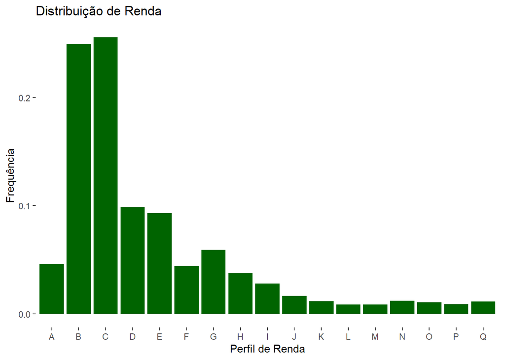

```r
ggplot(dfEnem, aes(x = Q006)) + geom_bar(aes(y = (..count..) / sum(..count..)),
                                         binwidth = 10,
                                         stat = "count",
                                         fill = "darkgreen") +
  theme(panel.background = element_blank())+
  labs(title="Distribuição de Renda", x = "Perfil de Renda", y ="Frequência")
```

> Verificamos que a maioria os estudantes estão no perfil C, com renda familiar entre R$998,01 e R$1497.

### Comparação entre as notas entre os perfis C e Q

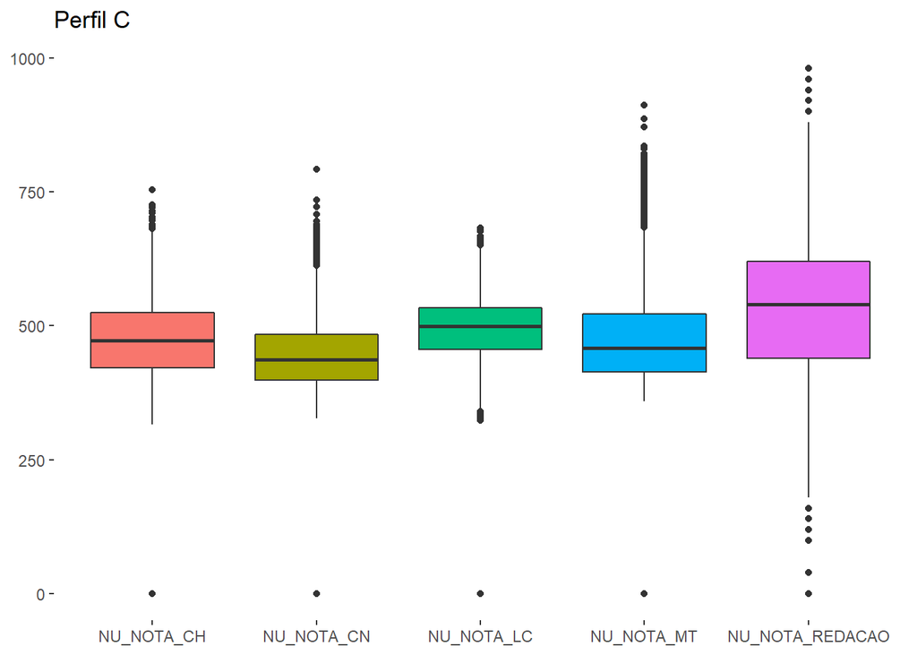

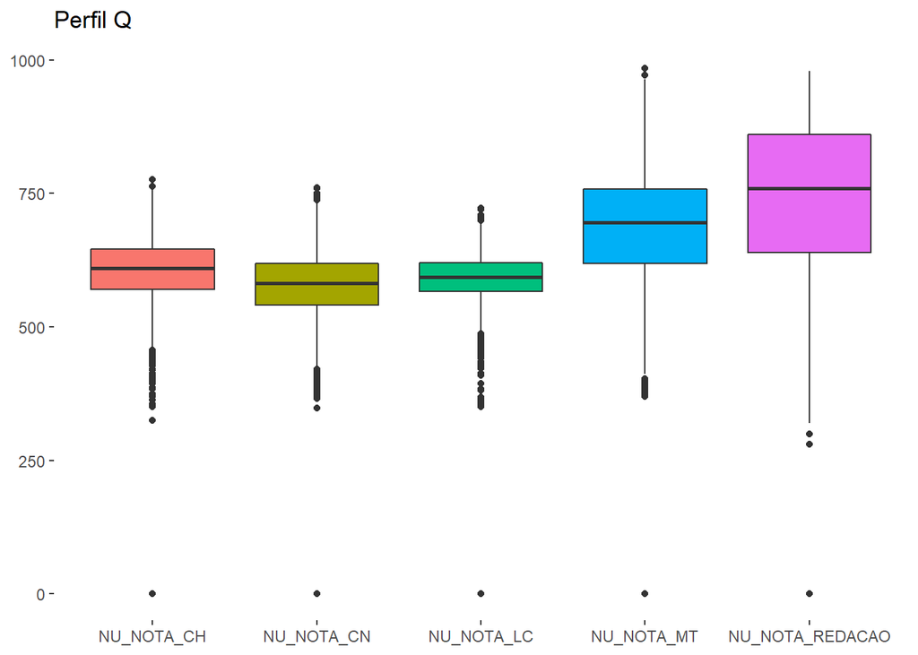

```r
par(mar = c(4, 4, .1, .1))
dfC %>% pivot_longer(-1) %>% ggplot(aes(x = name, y = value, fill = name)) +
  geom_boxplot() +
  theme(
    legend.position = "none",
    panel.background = element_blank(),
    axis.title.x = element_blank(),
    axis.title.y = element_blank()
  ) +
  ggtitle("Perfil C")
dfQ %>% pivot_longer(-1) %>% ggplot(aes(x = name, y = value, fill = name)) +
  geom_boxplot() +
  theme(
    legend.position = "none",
    panel.background = element_blank(),
    axis.title.x = element_blank(),
    axis.title.y = element_blank()
  ) +
  ggtitle("Perfil Q")
```

> Não é novidade que a desigualdade social tem impacto direto no desempenho escolar. Vemos que a classe com maior renda teve notas maiores. Destacam-se que os outliers estão na parte superior na classe C, enquanto que em Q os outliers estão na parte inferior. Em ambos os casos a Redação teve grande dispersão de notas.

## Analisando diferenças entre gêneros

##### Criando dataset para as notas

```r
dfNotas2 <-
  dfEnem[, c(
    "TP_SEXO",
    "NU_NOTA_CN",
    "NU_NOTA_CH",
    "NU_NOTA_MT",
    "NU_NOTA_LC",
    "NU_NOTA_REDACAO"
  )]
dfNotasTot <- dfNotas2
dfNotasTot$NU_NOTA_TOTAL <-
  rowSums(dfNotas2[, c("NU_NOTA_CN",
                       "NU_NOTA_CH",
                       "NU_NOTA_MT",
                       "NU_NOTA_LC",
                       "NU_NOTA_REDACAO")], na.rm = T)
```

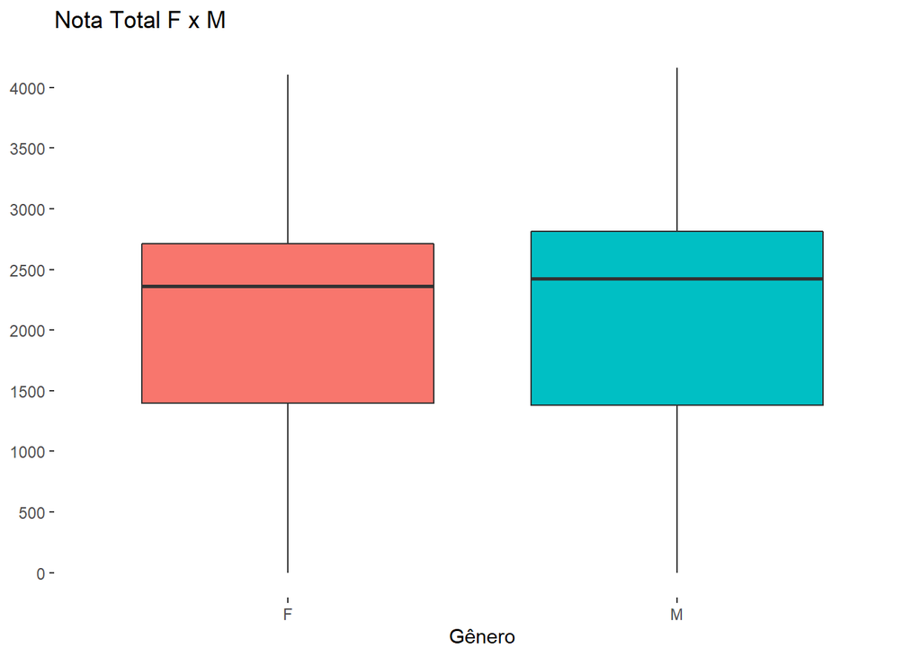

```r
ggplot(dfNotasTot, aes(x = TP_SEXO, y = NU_NOTA_TOTAL, fill = TP_SEXO)) +
  geom_boxplot() +
  theme(
    panel.background = element_blank(),
    legend.position = "none",
    axis.title.y = element_blank()
  ) +
  ggtitle("Nota Total F x M") +
  ylab("Nota Total") + xlab("Gênero") +
  scale_y_continuous(breaks = seq(
    min(dfNotasTot$NU_NOTA_TOTAL),
    max(dfNotasTot$NU_NOTA_TOTAL),
    500
  ))
```

> No geral, os meninos se saíram ligeiramente melhor que as meninas.

## Análise Geográfica

##### Carregando pacote com dados geográficos do Brasil

```r
Estados <- read_state(code_state="all")
```

##### Criando um dataset para as médias da nota total por Estado

```r
dfNotasTot$Estados <- dfEnem$SG_UF_RESIDENCIA

dfNotasMedia <- dfNotasTot %>%
  group_by(Estados) %>%
  summarise(Media = mean(NU_NOTA_TOTAL, na.rm = T))
```

##### Renomeando coluna para que seja igual à do dataset com dados geográficos

```r
dfNotasMedia <- dfNotasMedia %>% rename(abbrev_state = Estados)
```

##### Unindo os datasets para a plotagem do mapa

```r
Media_Mapa <- full_join(Estados, dfNotasMedia, by = "abbrev_state")
```

##### Para dividirmos em intervalos de classes, utilizei a função de Sturges para determinar um número de classes e a função cut2 para criar os intervalos automaticamente como referência

```r
nclass.Sturges(Media_Mapa$Media)
```

```
## [1] 6
```

```r
Media_Mapa$Grupo <- cut2(Media_Mapa$Media, g=6)
```

##### Atribuindo faixas de médias

```r
Media_Mapa$Grupo <-
  cut(Media_Mapa$Media,breaks = c(1500,1600,1700,1800,1900,2000,Inf),
      label=c("1500 a 1600","1601 a 1700","1701 a 1800","1801 a 1900","1901 a 2000",">2000"))
```

```
## Scale on map varies by more than 10%, scale bar may be inaccurate
```

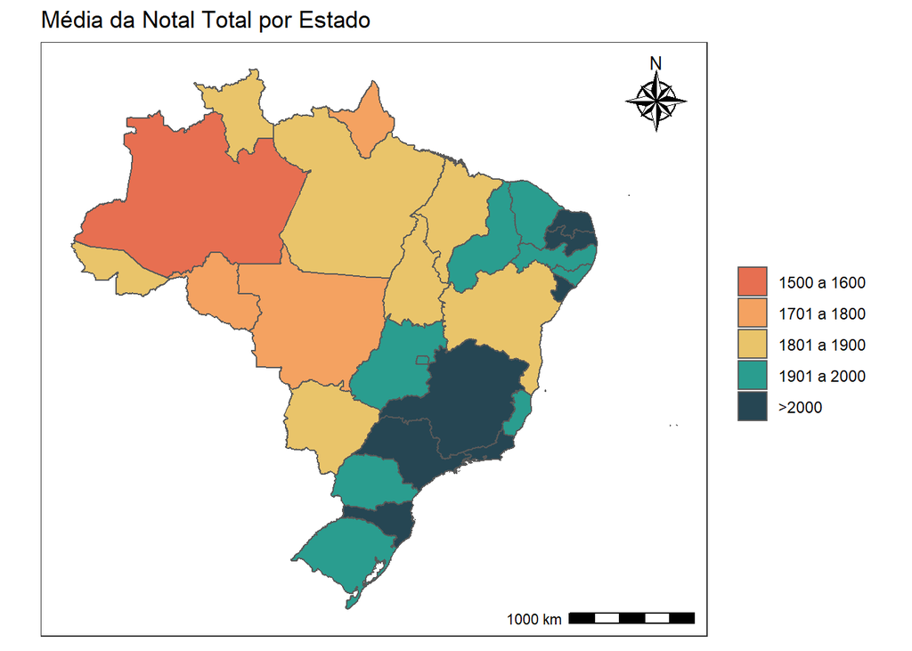

```r
ggplot(Media_Mapa) +
  geom_sf(aes(fill = Grupo)) +
  scale_fill_manual(values = c("#E76F51","#F4A261","#E9C46A","#2A9D8F","#264653"))+
  annotation_scale(location="br",height = unit(.2,"cm"))+
  annotation_north_arrow(location="tr",
                         style = north_arrow_nautical,
                         height=unit(1.5,"cm"),
                         width=unit(1.5,"cm"))+
  labs(title="Média da Notal Total por Estado",
       x=NULL,Y=NULL)+
  theme_bw()+
  theme(axis.text = element_blank(),
        panel.grid = element_blank(),
        axis.ticks = element_blank(),
        legend.title = element_blank())
```

## Análises de Desempenho

#### Qual seria a correlação entre as notas?

```r
#Criando dataset sem notas zeradas
df_sem_0 <- subset(dfNotasTot2, NU_NOTA_TOTAL > "0")
####Para facilitar a leitura, renomei as colunas com as disciplinas
colnames(df_sem_0)[1] <-"Ciências Naturais"
colnames(df_sem_0)[2] <-"Ciências Humanas"
colnames(df_sem_0)[3] <-"Matemática"
colnames(df_sem_0)[4] <-"Linguagens e Códigos"
colnames(df_sem_0)[5] <-"Redação"
colnames(df_sem_0)[6] <-"Total"
```

##### Dataset para as correlações:

```r
df_correlação <-round(cor(df_sem_0, use = "complete.obs"),2)
```

##### Criando uma visualização das correlações

```r
#Utilizando a função melted para listar as correlações
melted_corr <- melt(df_correlação)
```

```r
#Pegar parte inferior do triângulo da matriz de correlação
pegar_inferior_tri <-function(df_correlação){
  df_correlação[upper.tri(df_correlação)] <- NA
  return(df_correlação)
}
#Pegar parte superior do triângulo da matriz de correlação
pegar_superior_tri <-function(df_correlação){
  df_correlação[lower.tri(df_correlação)]<-NA
  return(df_correlação)
}
tri_superior <- pegar_superior_tri(df_correlação)
melted_corr <-melt(tri_superior, na.rm=TRUE)
colnames(tri_superior)[3]
```

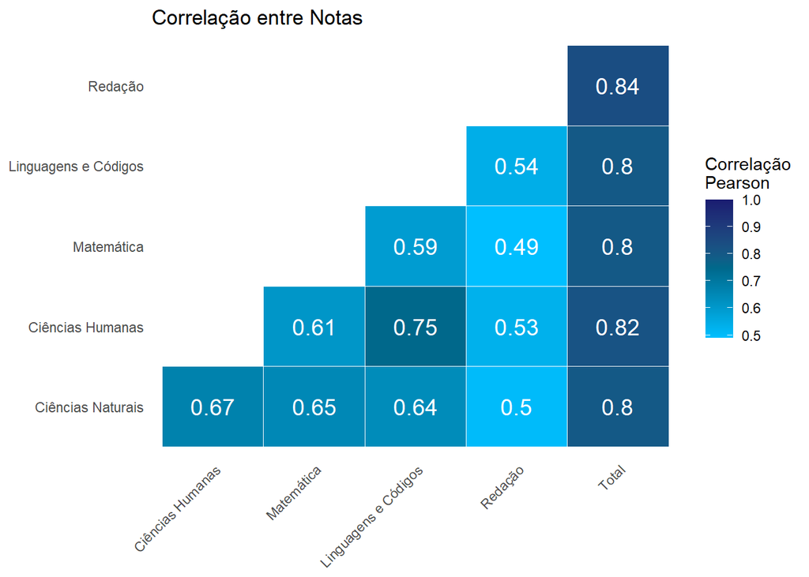

```r
#Limpando as correlações perfeitas
melted_corr[melted_corr==1] <- NA
melted_corr <- na.omit(melted_corr)

ggplot(data=melted_corr,aes(x=Var2,y=Var1, fill=value)) +
  geom_tile(color="white")+
  scale_fill_gradient2(low="deepskyblue1",mid="deepskyblue4",high="midnightblue",
                       midpoint = 0.75,limit=c(0.49,1),space="Lab",
                       name="Correlação\nPearson")+

  geom_text(aes(Var2,Var1,label=value),color ="white", size = 5)+
  theme(
    axis.title.x = element_blank(),
    axis.title.y = element_blank(),
    panel.grid.major = element_blank(),
    panel.border = element_blank(),
    axis.ticks = element_blank(),
    panel.background = element_blank(),
    axis.text.x = element_text(angle=45, vjust = 1, hjust=1)
  ) +ggtitle("Correlação entre Notas")
```

> Analisando os resultados, a nota de Ciências Humanas está fortemente correlacionada com Linguagens e Códigos, enquanto que entre notas de Redação e Matemática essa correlação é a menor.